# Final Project

Ranjani Namasivayam

12/18/2019

## The Microbiome and Tuberculosis

The project compares the clinical characteristics and microbiome of patients infected with different mycobacterial species (MTB and MAF) with that of healthy controls

Loading required R packages

```r
library(tidyr)
library(tibble)
library(dplyr)
library(tidyverse)
library(ggplot2)
library(ggpubr)
library(tableone)
library(cowplot)
library(microbiome)
```

Loading the clinical paramters dataset

```r
TB_clinical<-read_csv("/Volumes/namasivayams$/FAES_course/BIOF339/BIOF339_class/final_project/TB_clinical.csv")
kableone(head(TB_clinical))
```

| Participants | Group | Sex | Age | Smoking | Night_Sweats | Hb | Temperature |
| --- | --- | --- | --- | --- | --- | --- | --- |
| ID1 | Healthy | M | 26 | YES | NO | 9.2 | 36.2 |
| ID2 | Healthy | M | 20 | YES | NO | 16.0 | 36.4 |
| ID3 | Healthy | M | 25 | NO | NO | 16.5 | 37.2 |
| ID4 | Healthy | M | 28 | NO | NO | 14.1 | 36.4 |
| ID5 | Healthy | M | 24 | NO | NO | 10.0 | 36.1 |
| ID6 | Healthy | M | 21 | NO | NO | 13.2 | 36.8 |

Converting categorical variables to factors

```r
TB_clinical <- TB_clinical %>%
  mutate(Group = as.factor(Group),
         Sex = as.factor(Sex),
         Smoking = as.factor(Smoking),
         Night_Sweats = as.factor(Night_Sweats))
```

Some data munging to easily plot the factor and numerical variables

```r
TB_clinical_gathered1 <- gather(TB_clinical, key = Factor, value = Factor_value, -Participants, -Group, -Hb, -Temperature, -Age)
TB_clinical_gathered2 <- gather(TB_clinical, key = Numerical, value = Numerical_value, -Participants, -Group, -Sex, -Night_Sweats, -Smoking)
```

Visualizing the clinical data

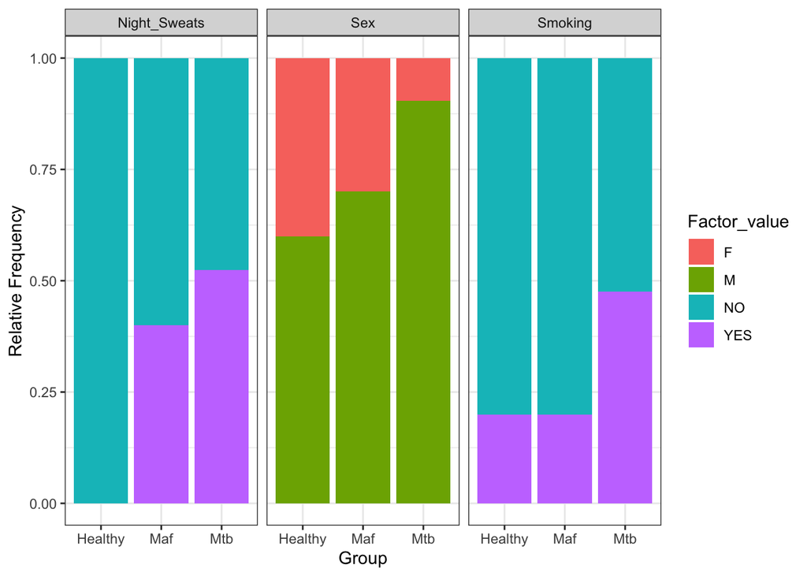

```r
TB_clinical_gathered1 %>%
  ggplot(mapping = aes(x=Group))+
  geom_bar(aes(fill=Factor_value), position = "fill") +
  facet_wrap(~ Factor, labeller= "label_value") +
  theme_bw()+
  labs(y= "Relative Frequency")
```

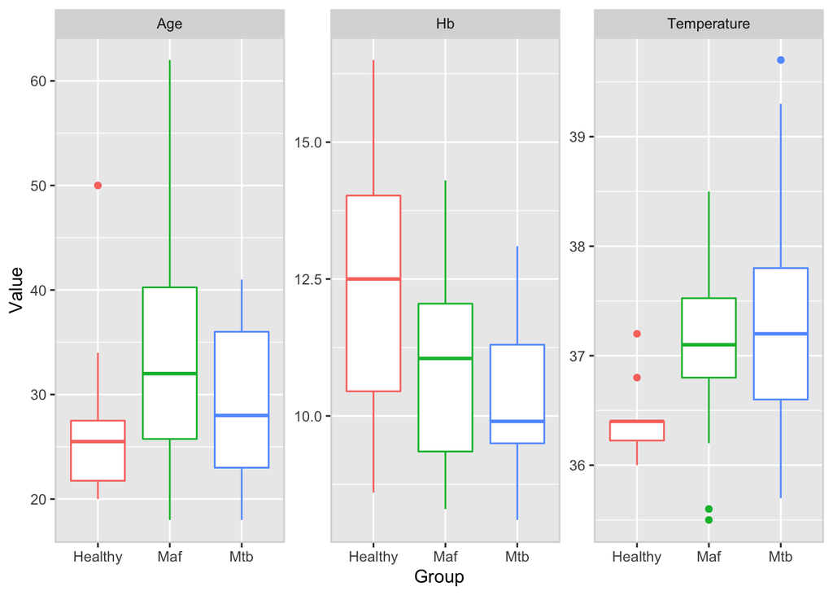

```r
TB_clinical_gathered2 %>%
  ggplot(mapping=aes(x=Group,y=Numerical_value,color=Group)) +
  geom_boxplot() +
  facet_wrap(~ Numerical, scales = "free_y") +
  theme(legend.position = "none") +
  panel_border() +
  labs(y= "Value")
```

Creating table one that displays statistical significance between healthy, MAF and MTB group

```r
Table1<-CreateTableOne(
  data = TB_clinical,
  vars = TB_clinical %>%
    select(-contains("Participants"),-contains("Group")) %>%
    names(),
  strata = 'Group',
  test = TRUE)
kableone(Table1)
```

|  | Healthy | Maf | Mtb | p | test |
| --- | --- | --- | --- | --- | --- |
| n | 10 | 20 | 21 |  |  |
| Sex = M (%) | 6 (60.0) | 14 (70.0) | 19 (90.5) | 0.119 |  |
| Age (mean (SD)) | 27.50 (8.90) | 33.70 (11.71) | 29.33 (7.77) | 0.192 |  |
| Smoking = YES (%) | 2 (20.0) | 4 (20.0) | 10 (47.6) | 0.112 |  |
| Night_Sweats = YES (%) | 0 ( 0.0) | 8 (40.0) | 11 (52.4) | 0.018 |  |
| Hb (mean (SD)) | 12.50 (2.71) | 10.96 (1.74) | 10.39 (1.33) | 0.015 |  |
| Temperature (mean (SD)) | 36.42 (0.35) | 37.12 (0.80) | 37.30 (1.04) | 0.033 |  |

Loading microbiome data for subset of subjects and merging using inner join to retain participants who have both clinical and microbiota data available. Also converting microbiota relative abudance to percent.

```r
TB_micro<-read_csv("/Volumes/namasivayams$/FAES_course/BIOF339/BIOF339_class/final_project/TB_microbiota.csv")
kableone(head(TB_micro))
```

| SampleID | Actinobacteria | Bacteroidetes | Firmicutes | Proteobacteria | Tenericutes | Verrucomicrobia |
| --- | --- | --- | --- | --- | --- | --- |
| ID21 | 0.0005681 | 0.6087789 | 0.3877527 | 0.0029004 | 0.0000000 | 0.0000000 |
| ID22 | 0.0068935 | 0.3598483 | 0.4679924 | 0.1565015 | 0.0026395 | 0.0000000 |
| ID23 | 0.0003017 | 0.4858034 | 0.2656632 | 0.2482317 | 0.0000000 | 0.0000000 |
| ID25 | 0.0000000 | 0.1758172 | 0.1077332 | 0.7164496 | 0.0000000 | 0.0000000 |
| ID26 | 0.0001280 | 0.4733799 | 0.0589164 | 0.4673623 | 0.0000000 | 0.0001494 |
| ID27 | 0.0001365 | 0.4072031 | 0.0643585 | 0.5266090 | 0.0016383 | 0.0000000 |

```r
TB_clinical_micro<-inner_join(TB_clinical, TB_micro, by=c('Participants'='SampleID'))
TB_clinical_micro<-TB_clinical_micro %>%
  mutate_at(vars(9:14), .funs = funs(. *100))
kableone(head(TB_clinical_micro))
```

| Participants | Group | Sex | Age | Smoking | Night_Sweats | Hb | Temperature | Actinobacteria | Bacteroidetes | Firmicutes | Proteobacteria | Tenericutes | Verrucomicrobia |
| --- | --- | --- | --- | --- | --- | --- | --- | --- | --- | --- | --- | --- | --- |
| ID1 | Healthy | M | 26 | YES | NO | 9.2 | 36.2 | 0.1341366 | 79.16562 | 12.01091 | 8.084574 | 0.1796067 | 0.0000000 |
| ID2 | Healthy | M | 20 | YES | NO | 16.0 | 36.4 | 0.6085575 | 61.88707 | 30.15860 | 7.345774 | 0.0000000 | 0.0000000 |
| ID3 | Healthy | M | 25 | NO | NO | 16.5 | 37.2 | 2.0354588 | 51.70446 | 43.29630 | 2.940953 | 0.0228276 | 0.0000000 |
| ID4 | Healthy | M | 28 | NO | NO | 14.1 | 36.4 | 1.3797913 | 30.47994 | 45.43100 | 14.627282 | 1.1780529 | 2.4358048 |
| ID5 | Healthy | M | 24 | NO | NO | 10.0 | 36.1 | 4.6390041 | 36.48133 | 49.07676 | 5.116183 | 4.5124481 | 0.0000000 |
| ID6 | Healthy | M | 21 | NO | NO | 13.2 | 36.8 | 1.8991655 | 55.64131 | 37.34227 | 4.015694 | 0.7607715 | 0.1455229 |

Some data munging to visualize a stacked bar chart of phyla for each group

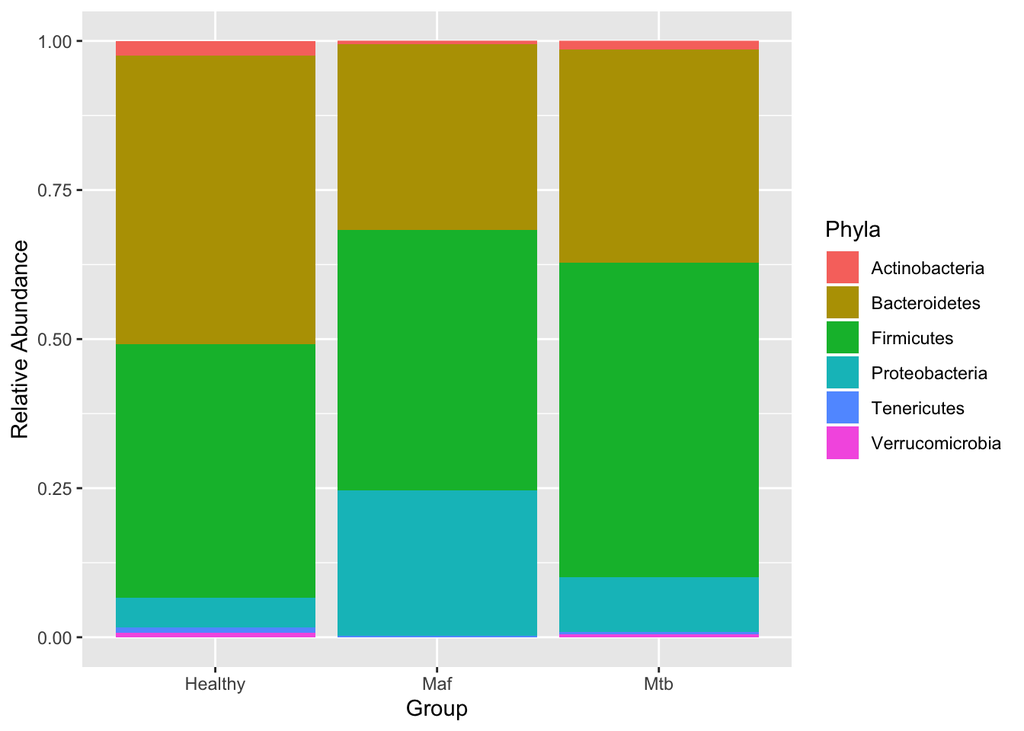

```r
TB_clinical_micro_gathered <- TB_clinical_micro %>%
  select(1:2, 9:14) %>%
  gather(key = Phyla, value = Abundance, -Participants, -Group)

TB_clinical_micro_gathered %>%
  ggplot(mapping=aes(fill=Phyla, x=Group, y=Abundance)) +
  geom_bar(position = "fill", stat = "identity") +
  labs(y= "Relative Abundance")
```

Calculating the statistical significance between the 3 groups for the microbiota data and displaying as table

```r
Table2<-CreateTableOne(
  data = TB_clinical_micro,
  vars = TB_clinical_micro %>%
    select(9:14) %>%
    names(),
  strata = 'Group',
  test = TRUE)

kableone(Table2)
```

|  | Healthy | Maf | Mtb | p | test |
| --- | --- | --- | --- | --- | --- |
| n | 10 | 19 | 20 |  |  |
| Actinobacteria (mean (SD)) | 2.42 (2.73) | 0.49 (0.66) | 1.36 (2.22) | 0.041 |  |
| Bacteroidetes (mean (SD)) | 48.06 (17.47) | 31.10 (16.65) | 35.11 (21.38) | 0.078 |  |
| Firmicutes (mean (SD)) | 42.24 (15.58) | 43.51 (25.19) | 51.64 (19.74) | 0.390 |  |
| Proteobacteria (mean (SD)) | 5.00 (4.38) | 24.36 (27.34) | 9.06 (13.39) | 0.016 |  |
| Tenericutes (mean (SD)) | 0.92 (1.41) | 0.19 (0.28) | 0.41 (0.77) | 0.083 |  |
| Verrucomicrobia (mean (SD)) | 0.71 (1.48) | 0.00 (0.01) | 0.43 (0.92) | 0.107 |  |

Visualizing the abundance of taxa significantly different between groups stratified by the clinical factor that was significantly different (night sweats)

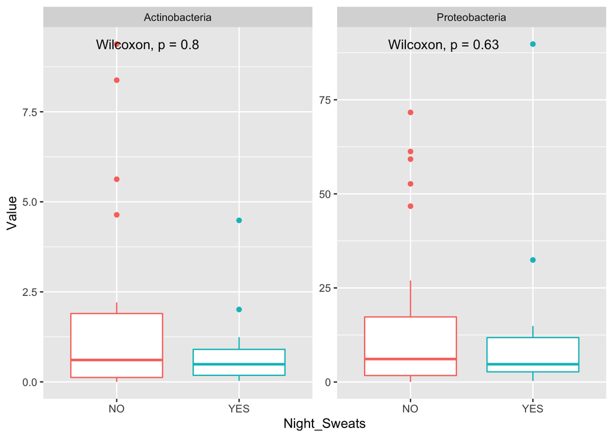

```r
TB_clinical_micro_gathered2 <- TB_clinical_micro %>%
  select(1:2, 9:14, contains("Sex"), contains("Night_Sweats"), contains("Smoking")) %>%
  gather(key = Phyla, value = Abundance, -Participants, -Group, -Sex, -Night_Sweats, -Smoking)

TB_clinical_micro_gathered2 %>%
  filter(Phyla == "Actinobacteria" | Phyla == "Proteobacteria") %>%
  ggplot(mapping=aes(x=Night_Sweats,y=Abundance,color=Night_Sweats)) +
  geom_boxplot() +
  facet_wrap(~ Phyla, scales = "free_y") +
  theme(legend.position = "none") +
  labs(y= "Value") +
  stat_compare_means()
```

Performing correlation analysis between numerical clinical paramters and relative abundance of phyla

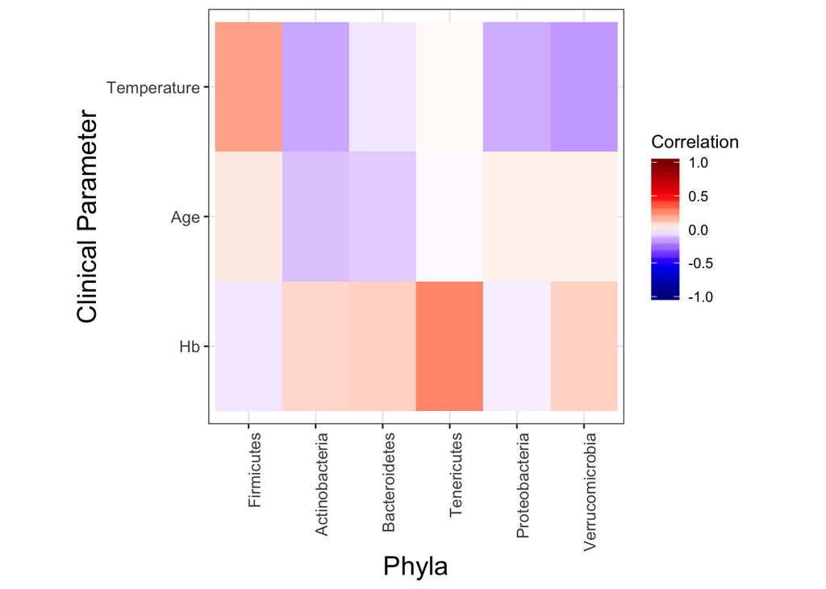

```r
data_x1<- TB_clinical_micro %>%
  select(contains("Age"), contains("Hb"), contains("Temperature")) %>%
  as.matrix()

data_x2<- TB_clinical_micro %>%
  select(9:14) %>%
  as.matrix()

data_x1_vs_x2 <- associate(data_x1, data_x2, method = "spearman", mode = "table")

heat(data_x1_vs_x2, "X2", "X1", fill = "Correlation") +
  labs(x = "Phyla", y = "Clinical Parameter") +
  theme_bw() +
  theme(aspect.ratio = 1) +
  theme(axis.text.y = element_text(size = 10)) +
  theme(axis.text.x = element_text(size = 10, angle = 90, hjust = 1)) +
  theme(axis.title = element_text(size = 16)) +
  scale_fill_gradientn("Correlation", breaks = seq(from = -1, to = 1, by = 0.5), colours = c("darkblue", "blue", "white", "red", "darkred"), limits = c(-1,1))
```